# 06_analysis_2.qmd

Author

group_12

# Master document

01_load.qmd contains the script that loads all the raw data we used in the project

## Extract data

Load all the datasets we used and processed throughout the study analysis

```r
library("tidyverse")
library("maps")
library("ggplot2")
library("viridis")
```

**Load data**

```r
filename <-  c("DONsRaw.csv",
               "COVIDOutbreaks.csv",
               "Outbreaks.csv",
               "UniqueDONs.csv",
               "icd1011.csv",
               "isocodes.csv",
               "WDICountry.csv",
               "world-administrative-boundaries.csv")
dir_name <- "../_raw/"

if( !dir.exists(dir_name) ){
  dir.create(path = dir_name)
}

if ( length(list.files(dir_name,
                       pattern="csv")) != length(filename) ) {
  print(str_c(str_flatten_comma(filename,),
              " required in _raw folder"))

} else if ( length(list.files(dir_name,
                              pattern="csv")) == length(filename)) {
  rawdons <-  read.csv(str_c(dir_name,
                             "DONsRaw.csv"))
  covidOutbreaks <- read.csv(str_c(dir_name,
                                   "COVIDOutbreaks.csv"),
                             sep = ",")
  outbreaks <- read.csv(str_c(dir_name,
                              "Outbreaks.csv"),
                        sep = ",")
  uniqueDONs <- read.csv(str_c(dir_name,
                               "UniqueDONs.csv"),
                         sep = ",")
  wdi <- read.csv(str_c(dir_name,"WDICountry.csv"))
  worldboundaries <- read.csv(str_c(dir_name,
                                    "world-administrative-boundaries.csv"),
                              sep = ";")
  icd1011 <- read.csv(str_c(dir_name,
                            "icd1011.csv"),
                      sep =";")
  isocodes <- read.csv(str_c(dir_name,
                             "isocodes.csv"),
                       sep = ";")
}
```

02_clean.qmd contains the cleaning process we followed to optimize the data format for the project

## CLEANING DATA

This file contains the steps we followed to clean the data-sets we used in the study analysis.

## CLEAN WDI DATA:

**We keep only the variables needed, and rename Country.Code to iso3 for merging purposes. Renaming Kosovo iso3, as there is no universally accepted code, and they differ in the world bank (XKX) and WHO (XXK). We filter to include only countries with income data available. :**

```r
wdi_clean <- wdi |>
  select(Country.Code, Income.Group) |>
  rename(iso3 = Country.Code) |>
  mutate(iso3 = if_else(iso3 == "XKX",
                        "XXK",
                        iso3)) |>
  filter(Income.Group !="")
```

## CLEAN WORLD BOUNDARIES DATA:

**Removing rows with blank cells:**

```r
worldboundaries <- worldboundaries |>
  filter_all(all_vars(. != ""))
```

**Renaming iso3, Continent and Coordinates column and removing not needed columns:**

```r
worldboundaries <- worldboundaries |>
  rename(
    iso3 = "ISO.3.country.code",
    Continent = "Continent.of.the.territory",
    Coordinates = "Geo.Point") |>
  select(-French.Name,
         -English.Name,
         -ISO.3.territory.code,
         -Region.of.the.territory,
         -ISO.3166.1.Alpha.2.Codes,
         -Geo.Shape)
```

**Correcting iso3 and discarding rows with wrong iso3-Continent combination:**

```r
worldboundaries <- worldboundaries |>
  mutate(
    iso3 = case_when(
      iso3 == "United States of America" ~ "USA",
      iso3 == "Brazil" ~ "BRA",
      TRUE ~ iso3
    ),
    Continent = case_when(
      Continent %in% c("Northern America",
                       "South America") ~ "Americas",
      TRUE ~ Continent
    )
  ) |>
  filter(
    !(Continent != "Americas" & iso3 == "USA") &
    !(Continent != "Europe" & iso3 %in% c("GBR",
                                          "FRA"))
  )
```

**Removing rows with duplicates of the same iso3:**

```r
worldboundaries <- worldboundaries |>
  distinct(iso3,
           .keep_all = TRUE)
```

## CLEAN RAW DONs:

**Changing the column names:**

```r
rawdons_clean <- rawdons|>
  rename(DONs = ID) |>
  mutate(Year = as.integer(str_split_i(Date,
                                       pattern = "-",
                                       1)))
```

## CLEAN UNIQUE DONs and COVID-19 DATA:

**Rename of column, handling null and unspecific values:**

```r
uniqueDONs_clean <- uniqueDONs |>
  rename(Index = X) |>
  mutate(Definition = if_else(Definition == "",
                              "Unspecified",
                              Definition),
         icd11l2 = if_else(icd11l2 == "",
                           "Not reported",
                           icd11l2),
                           icd11l3 = if_else(icd11l3 == "",
                                             "Not reported",
                                             icd11l3),
                           icd11l2 = if_else(str_detect(icd11l2,
                                                        "Aetiology"),
                                             "Bacteria or viral infection",
                                             icd11l2))

covidOutbreaks_clean <- covidOutbreaks |>
  rename(Index = X) |>
  mutate(
    icd11c1 = as.character(icd11c1),
    icd11l2 = if_else(str_detect(icd11l2,
                                 "International"),
                      "New uncertain disease",
                      icd11l2))
```

## MERGING DATA

**Merging of unique and COVID-19 outbreaks data:**

```r
total_outbreaks <-
  full_join(uniqueDONs_clean,
            covidOutbreaks_clean) |>
  distinct()
```

[output not shown]

**Merging of WDI and total outbreaks data:**

```r
outbreaks_wdi <-
  left_join(total_outbreaks,
            wdi_clean,
            by = "iso3")
```

**Merging of geographical and total outbreaks data:**

```r
clean_outbreaks <- worldboundaries |>
  left_join(drop_na(outbreaks_wdi),
            by = "iso3")
```

## Cleaning merged data

**Correcting/Shortening countries names:**

```r
clean_outbreaks <- clean_outbreaks |>
  mutate(
    Country = case_when(
      Country == "Congo Democratic Republic of the" ~ "Democratic Republic of Congo",
      Country == "United States of America" ~ "USA",
      Country== "C̫te d'Ivoire" ~ "Côte d'Ivoire",
      Country == "United Kingdom of Great Britain and Northern Ireland" ~ "United Kingdom",
      TRUE ~ as.character(Country)
    )
  )
```

**Removing missing values**

```r
#clean_outbreaks <- drop_na(clean_outbreaks)
```

**Creating a final clean data file: clean_outbreaks**

```r
write_tsv(clean_outbreaks, "../_raw/clean_outbreaks.tsv")
```

## Creation of new variables

This file contains the new variables useful for our analysis

## Data scraping

The isocodes dataset is used to scrape the column *Description* for matching countries. The first value that is extracted is then added to a new column called Country- representing each country that an outbreak originated in

```r
countries <-isocodes |>
  distinct(Country) |>
  format_delim(delim="|",
               eol = "|",
               col_names = FALSE) |>
  str_sub(end =-2)

uniqdisease <- uniqueDONs_clean |>
  select(Country,
         DONs,
         Disease) |>
  separate_longer_delim(DONs,
                        delim = ",",) |>
  mutate(DONs=str_remove(DONs," "))


rawdons_aug <- rawdons_clean |>
  mutate(
    Country = sapply(str_extract_all(Description,
                                     str_c("United Kingdom|
                                           Côte d'Ivoire|
                                           Hong Kong|
                                           Republic of Korea|
                                           Tanzania|Iran|
                                           United States|
                                           Lao People's Democratic Republic|
                                           Venezuela|saudi_arabia|
                                           Bolivia|",
                                           countries)),
                     function(x) paste(unique(x),
                                       collapse = ','))) |>
  separate_longer_delim(Country,
                        delim = ",")

# if country is na find the corresponding don in uniquedisease and fill corresponding country
rawdons_aug <- rawdons_aug |>
  mutate(Country = na_if(Country,
                         ""))
```

## The Isocodes

The isocodes are a collection of short country codes for each country and they are merged by the country to created a new object

```r
isocodesaug <- isocodes |>
  select(iso2,
         iso3,
         Country)

rawdons_aug <-rawdons_aug |>
  mutate(Country = str_replace_all(
    Country, c("Democratic Republic of the Congo" = "Congo Democratic Republic of the",
               "Republic of Korea" = "Korea Republic of",
               "United Republic of Tanzania" = "Tanzania United Republic of"))) |>
  left_join(isocodesaug,
            join_by(Country))
```

## The ICD codes

The disease that is associated with each DON is taken from the completed dataframe *uniquedons.csv*. Then the icd codes, which are a collection of disease descriptions, are merged to create a dataframe with all associated dons, disease and disease descriptions

```r
rawdons_aug <-rawdons_aug |>
  left_join(uniqdisease,
            join_by(DONs,
                    Country))

rawdons_aug <- rawdons_aug |>
  filter(!is.na(Disease)) |>
  mutate(Disease = ifelse(is.na(Disease),
                          DONs,
                          Disease)) |>
  left_join(icd1011, join_by(Disease))
```

## Data Specifics

The Dons that are not related to disease outbreaks are then deleted, such as meetings of international experts (see DON0133), recommendations on treatments (DON0153), or travel requirements (DON0107 and DON0198).

```r
rawdons_aug <- rawdons_aug |>
  filter(DONs != "DON0133"&
         DONs != "DON0153"&
         DONs!="DON0107"&
         DONs != "DON0198") |>
  arrange(Country) |>
  mutate(Country = ifelse((Disease == "Anthrax,
                           unspecified" & Year == "2001"),
                          "United States",
                          Country))
```

## Duplicate Removal

Combine all dons from the same outbreak into one column by removing duplicates. Deleting all the DONs registering the information on the same disease for the same country more than once in a given calendar year. This create a file with 1233 unique dons out of the original 1566. This is due to the fact that the paper obtained these missing countries from web scraping the titles as well as the description which was not the approach that was used here. The following analysis will use the completed using the *uniquedons* variable.

```r
rawdons_aug <-rawdons_aug |>
  mutate(key = as.factor(paste0(iso3,
                                Year,
                                icd104c))) |>
  group_by(key) |>
  mutate(AllDONs = paste(DONs,
                         collapse = ", ")) |>
  ungroup() |>
  distinct(Country,
           iso2,
           iso3,
           Year,
           icd10n,
           icd103n,
           icd104n,
           icd10c,
           icd103c,
           icd104c,
           icd11c1,
           icd11c2,
           icd11c3,
           icd11l1,
           icd11l2,
           icd11l3,
           Disease,
           Definition,
           AllDONs) # 1566 unique events apparently but only have 1233 so far as 271 countries are not named in Description column
```

## Augment the clean merged data file.

New column added for the the classification of different diseases types. COVID-19, Influenza and Cholera were not included in any category as they are major outbreaks and we wanted to show their influence separately.

```r
final_outbreaks <- clean_outbreaks |>
  mutate(icd11l2 = str_trim(icd11l2)) |>
   mutate(Disease_class = case_when(icd11l2 %in%
                                      c("Certain arthropod-borne viral fevers",
                                        "Certain zoonotic bacterial diseases",
                                        "Certain zoonotic viral diseases",
                                        "Dengue") ~ "Zoonotic diseases",
                                    icd11l2 %in%
                                      c("Bacteria or viral infection",
                                        "Certain other viral diseases",
                                        "Viral hepatitis",
                                        "Human immunodeficiency virus disease",
                                        "Viral infections characterised by skin or mucous membrane lesions",
                                        "Viral infections of the central nervous system",
                                        "Lung infections",
                                        "Human prion diseases") ~ "Viral infections",
                                    icd11l2 %in%
                                      c("Other bacterial diseases",
                                        "Mycobacterial diseases",
                                        "Sepsis",
                                        "Predominantly sexually transmitted infections",
                                        "Mycoses") ~ "Bacteria and fungus infections",
                                    icd11l2 %in% c("Parasitic diseases",
                                                   "Nonintestinal protozoal diseases") ~ "Parasitic infections",
                                    icd11l2 == "Gastroenteritis or colitis of infectious origin" ~ "Cholera-Intestinal diseases",
                                    icd11l2 == "Influenza" ~ "Influenza infections",
                                    icd11l2 == "Not reported" ~ "Uncertain diseases",
                                    icd11l2 == "New uncertain disease" ~ "Covid-19"))
```

For income data, we replace the “NA”s with a category called “No income data available”.

```r
  final_outbreaks <- final_outbreaks |>
  mutate (Income.Group = if_else(is.na(Income.Group),
                                 "No income data available",
                                 Income.Group))
```

#### Splitting Coordinates into Latitude and Longitude columns

```r
final_outbreaks <- final_outbreaks |>
  mutate(
    Coordinates = str_split(as.character(Coordinates),
                            ", ",
                            simplify = TRUE),
    Latitude = as.numeric(Coordinates[, 1]),
    Longitude = as.numeric(Coordinates[, 2])
  ) |>
  select(-Coordinates)
```

## Creating a final (clean and augmented datafile) to use for data-analysis: final_outbreaks

```r
write_tsv(final_outbreaks, "../_raw/final_outbreaks.tsv")
```

## Analysis

These two files contain the data analysis including plots and figures.

## Including the final clean and augmented dataset

```r
#final_outbreaks <- read_tsv("../_raw/Data/final_outbreaks.tsv")
```

### Reshaping data set to wide format and adding frequency column (Freq):

```r
geo_outbreaks_wide <- final_outbreaks |>
  count(Country,
        iso3,
        icd104c,
        Continent,
        Longitude,
        Latitude) |>
  pivot_wider(
    id_cols = c("Country",
                "iso3",
                "Continent",
                "Longitude",
                "Latitude"),
    names_from = icd104c,
    values_from = n,
    values_fill = 0
  )
geo_outbreaks_wide <- geo_outbreaks_wide |>
  mutate(Freq = rowSums(select(geo_outbreaks_wide,
                               where(is.numeric),
                               -Latitude,
                               -Longitude)))
```

#### Barplot of the 20 Countries with the highest number of outbreaks (1996 - 2022):

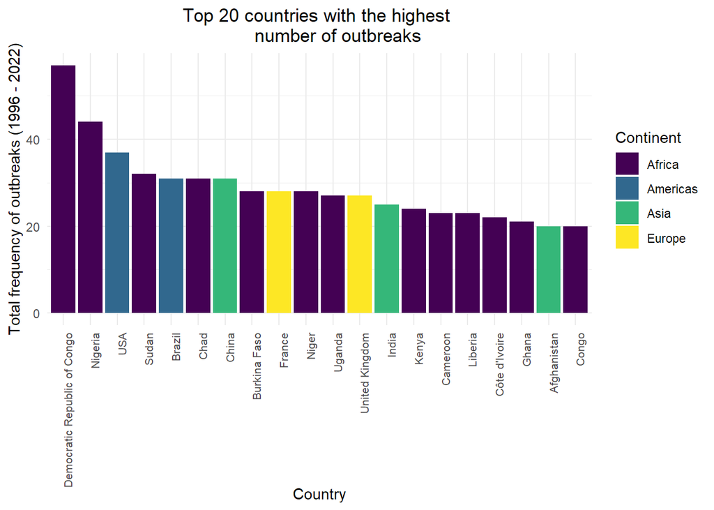

```r
# Select the top 20 countries and arrange the data
top_countries <- geo_outbreaks_wide  |>
  arrange(desc(Freq))  |>
  slice_head(n = 20)  |>
  mutate(Country = fct_reorder(Country,
                               Freq))  |>
  pull(Country)

# Plot the top 20 countries
fig4a_reproduced <- geo_outbreaks_wide  |>
  filter(Country %in% top_countries)  |>
  ggplot(aes(x = fct_reorder(Country,
                             -Freq),
             y = Freq,
             fill = Continent)) +
  geom_bar(stat = "identity") +
  labs(y = "Total frequency of outbreaks (1996 - 2022)",
       x = "Country",
       title = "Top 20 countries with the highest
       number of outbreaks"
       ) +
  theme_minimal() +
  scale_fill_viridis_d(alpha = 1) +
  theme(axis.text.x = element_text(angle = 90,
                                   hjust = 1, size = 8),
        plot.title = element_text(hjust = 0.5))

fig4a_reproduced
```

```r
ggsave(fig4a_reproduced,
       filename = "../Results/fig4a_reproduced.png",
       dpi = 300)
```

#### Map plot with the spatial frequency of outbreaks

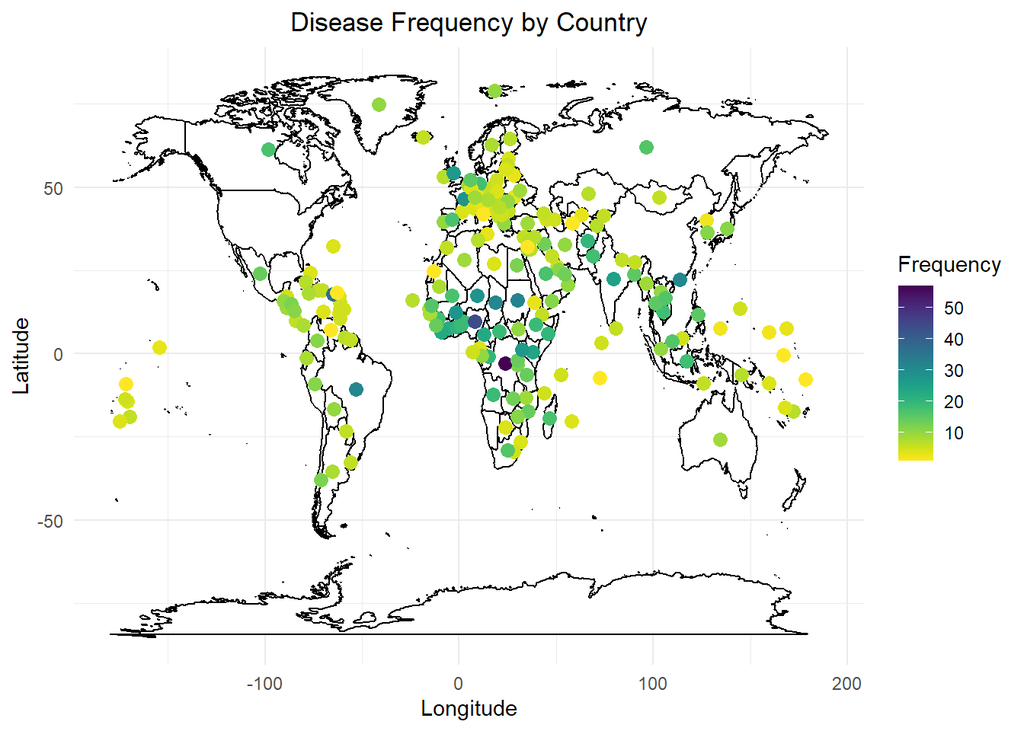

```r
# Download world map data
world <- map_data("world")

fig3_reproduced <- ggplot() +
  geom_polygon(data = world,
               aes(x = long,
                   y = lat,
                   group = group),
               fill = "white",
               color = "black") +
  geom_point(data = geo_outbreaks_wide,
             aes(x = Longitude,
                 y = Latitude,
                 color = Freq),
             size = 3) +
  scale_color_viridis(name = "Frequency",
                      direction = -1) +
  labs(title = "Disease Frequency by Country",
       x = "Longitude",
       y = "Latitude"
       ) +
  theme_minimal() +
  theme(plot.title = element_text(hjust = 0.5))

fig3_reproduced
```

```r
ggsave(fig3_reproduced,
       filename = "../Results/fig3_reproduced.png",
       dpi = 300)
```

### Reshaping data set to obtain the total yearly outbreaks:

```r
outbreaks_yearly <- final_outbreaks |>
  count(Year,
        icd104c) |>
  pivot_wider(names_from = icd104c,
              values_from = n,
              values_fill = 0)
outbreaks_yearly <- outbreaks_yearly |>
  mutate(Freq = rowSums(select(outbreaks_yearly,
                               where(is.numeric),
                               -Year)))
```

#### Barplot of the yearly number of outbreaks:

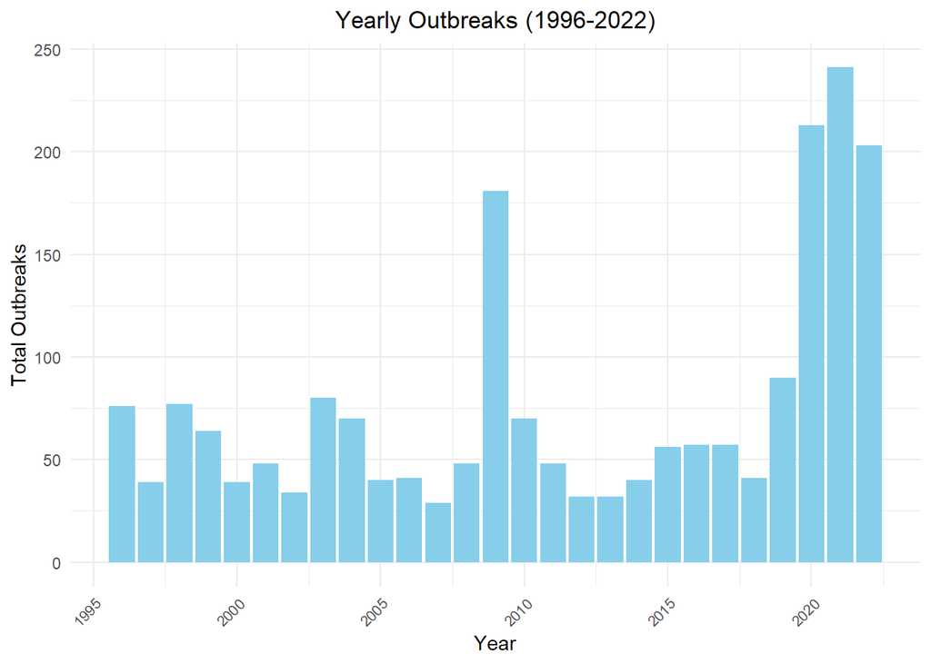

```r
# Plot the barplot
fig4c_reproduced <- ggplot(outbreaks_yearly,
                aes(x = Year,
                    y = Freq)) +
  geom_bar(stat = "identity",
           fill = "skyblue") +
  labs(title = "Yearly Outbreaks (1996-2022)",
       x = "Year",
       y = "Total Outbreaks"
       ) +
  theme_minimal() +
  theme(axis.text.x = element_text(angle = 45,
                                   hjust = 1,
                                   size = 8),
        plot.title = element_text(hjust = 0.5))

fig4c_reproduced
```

```r
ggsave(fig4c_reproduced,
       filename = "../Results/fig4c_reproduced.png",
       dpi = 300)
```

## Including the final clean and augmented dataset

```r
#final_outbreaks <- read_tsv("../_raw/Data/final_outbreaks.tsv")
```

## Disease-outbreaks, reproducing fig4b with top 20 diseases

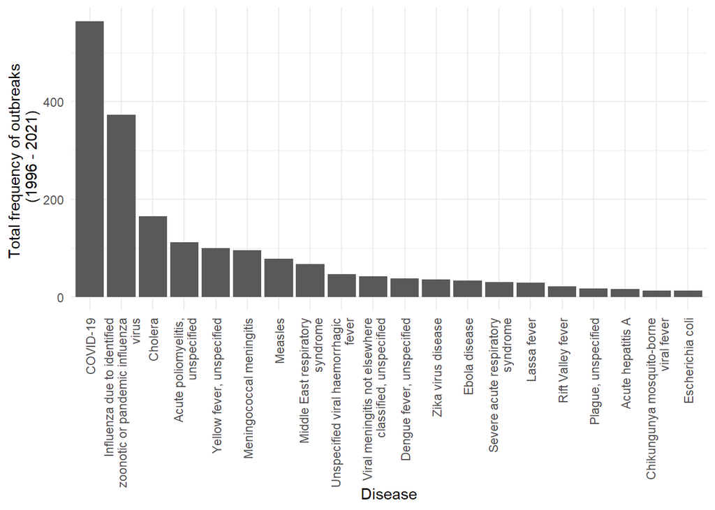

```r
#keeping the 20 most frequent diseases
#the fct_infreq orders the Disease in levels according to frequency
#the str_wraps wraps text that is over 30 characters

Fig4b_reproduced <- final_outbreaks |>
  count(Disease) |>
  arrange(desc(n)) |>
  slice_head(n = 20) |>
  inner_join(final_outbreaks, by = "Disease")  |>
  mutate(Disease = fct_infreq(Disease))  |>
  ggplot(mapping = aes(x = Disease)) +
  geom_bar()+
  labs(y = "Total frequency of outbreaks \n (1996 - 2021)",
       x = "Disease") +
  scale_x_discrete(labels = function(x) str_wrap(x,
                                                 width = 30)) +
  theme_minimal() +
  theme(axis.text.x = element_text(angle = 90,
                                   vjust = 0.5,
                                   hjust = 1))

Fig4b_reproduced
```

```r
ggsave(Fig4b_reproduced,
       filename = "../Results/Fig4b_reproduced.png",
       dpi = 300)
```

## Creating a new Figure 4b, with incorporated information on country income status

```r
final_outbreaks |>
  group_by(Income.Group) |>
  count()
```

```
# A tibble: 5 × 2
# Groups:   Income.Group [5]
  Income.Group                 n
  <chr>                    <int>
1 High income                560
2 Low income                 468
3 Lower middle income        607
4 No income data available     8
5 Upper middle income        411
```

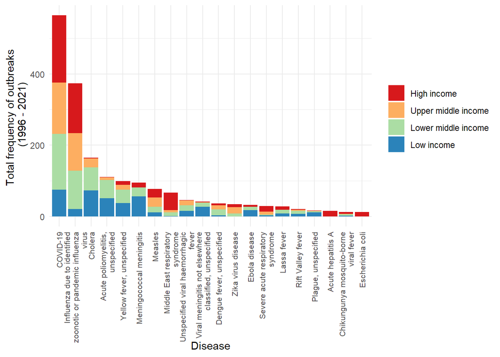

```r
Fig4b_income <- final_outbreaks |>
  count(Disease) |>
  arrange(desc(n)) |>
  slice_head(n = 20) |>
  inner_join(final_outbreaks,
             by = "Disease")  |>
  mutate(Disease = fct_infreq(Disease),
         Income.Group = factor(Income.Group,
                                levels = c("High income",
                                           "Upper middle income",
                                           "Lower middle income",
                                           "Low income",
                                           "No income data available"))) |>
  ggplot(mapping = aes(x = Disease,
                       fill = Income.Group)) +
  geom_bar()+
  scale_fill_brewer(palette = "Spectral") +
  labs(y = "Total frequency of outbreaks \n (1996 - 2021)",
       x = "Disease") +
  scale_x_discrete(labels = function(x) str_wrap(x,
                                                 width = 30)) +
  theme_minimal() +
  theme(axis.text.x = element_text(angle = 90,
                                   vjust = 0.5,
                                   hjust = 1,
                                   size = 8),
        legend.title = element_blank())

Fig4b_income
```

```r
ggsave(Fig4b_income,
       filename = "../Results/Fig4b_income.png",
       dpi = 300)
```

## Disease type distribution over the years 1996-2022

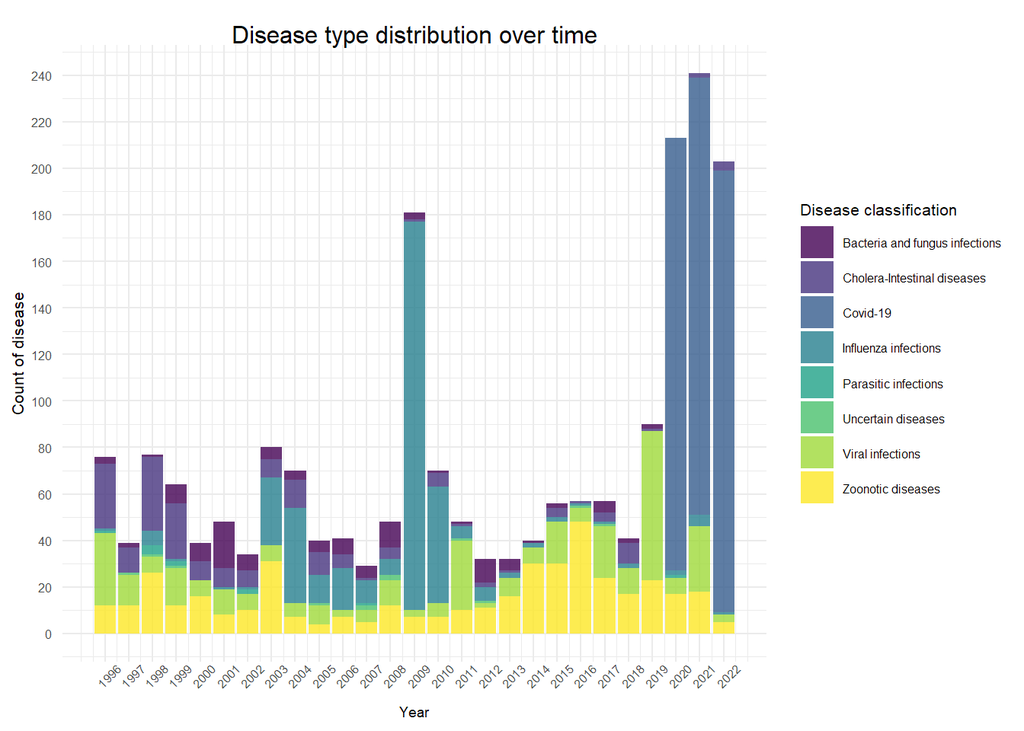

```r
Disease_distribution <- final_outbreaks |>
  drop_na() |>
  ggplot(mapping =
           aes(x = Year,
               fill = Disease_class,
               group = Disease_class)) +
  geom_bar(stat = "count") +
  scale_x_continuous(breaks = seq(1996,
                                  2022,
                                  by = 1)) +
  scale_y_continuous(breaks = seq(min(0),
                                  max(300),
                                  by = 20)) +
  theme_minimal() +
  scale_fill_viridis_d(alpha = 0.8) +
  theme(plot.title = element_text(size = 12,
                                  vjust = -2,
                                  hjust = 0.5),
        axis.title.x = element_text(size = 7),
        axis.title.y = element_text(size = 8),
        axis.text.x = element_text(size = 6,
                                   angle = 45),
        axis.text.y = element_text(size = 6),
        legend.title = element_text(size = 8),
        legend.text = element_text(size = 6)) +
  labs(x = "Year",
       y = "Count of disease",
       title = "Disease type distribution over time",
       fill = "Disease classification")

 ggsave(Disease_distribution,
        filename = "../Results/Disease_distribution.png",
        dpi = 300)
Disease_distribution
```

## Frequency of outbreaks for countries grouped by income in years 1996-2022

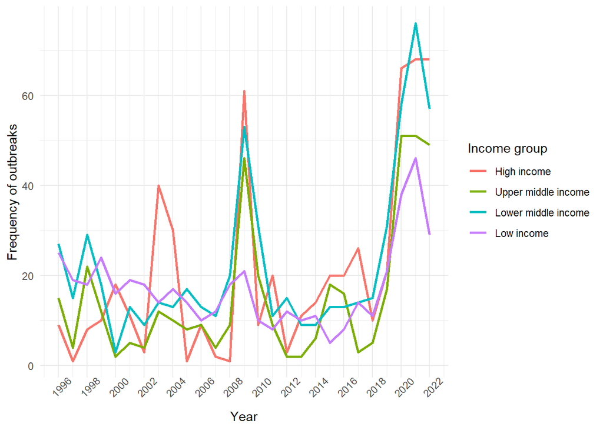

```r
# calculating the number of outbreaks in countries grouped by income
A1 <- final_outbreaks |>
  select(Income.Group,
         Year) |>
  drop_na() |>
  mutate(one = 1) |>
  pivot_wider(names_from =Income.Group,
              values_from = one,
              values_fn = sum)

A2 <- A1 |>
  pivot_longer(cols = -Year,
               names_to ="Income.Group",
               values_to = "Frequency")


#arranging data in an appropriate order
A2 <- A2 |>
  mutate(Income.Group = factor(Income.Group,
                          levels=c("High income",
                                   "Upper middle income",
                                   "Lower middle income",
                                   "Low income"
                                   )))

#making plot
Inc_line <- ggplot(data = A2,
                aes(x = Year,
                    y = Frequency,
                    color = Income.Group,
                    group = Income.Group
                    )) +
          geom_line(size = 1) +
      ylab("Frequency of outbreaks") +
      xlab("Year") +
  theme_minimal() +
  theme(axis.text.x = element_text(angle = 45)) +
  theme(legend.position = "right")+
   #scale_color_viridis_d() +
  scale_x_continuous(breaks = seq(1996,
                                  2022,
                                  by = 2))+
   labs(color = "Income group")
#saving graph
ggsave(Inc_line,
       filename ="../Results/Inc_line.png",
       dpi = 300)
Inc_line
```

## Frequency of outbreaks for each continent in years 1996-2022

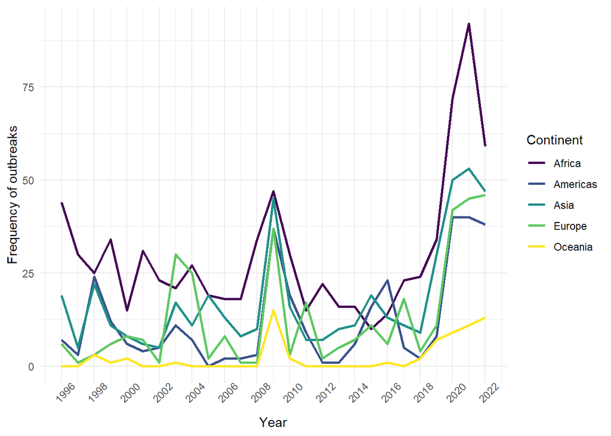

```r
# calculating the number of outbreaks in countries grouped by continent
B1 <- final_outbreaks |>
  select(Continent,
         Year) |>
  mutate(one = 1) |>
  pivot_wider(names_from = Continent,
              values_from = one,
              values_fn = sum)
B2 <- B1 |>
  pivot_longer(cols = -Year,
               names_to = "Continent",
               values_to = "Frequency")
#replacing NA's with 0 value as there was no information of an outbreak for a specific continent in a specific year
B2 <-B2 |>
  mutate(Frequency = replace_na(Frequency, 0))

#plot Frequency of outbreaks for each continent in years 1996-2022
Cont_line <- ggplot(data = B2,
                aes(x = Year,
                    y = Frequency,
                    color = Continent,
                    group = Continent)) +
          geom_line(size = 1) +
      ylab("Frequency of outbreaks") +
      xlab("Year") +
  theme_minimal() +
  theme(axis.text.x = element_text(angle = 45)) +
  theme(legend.position="right")+
  scale_color_viridis_d() +
  scale_x_continuous(breaks = seq(1996,
                                  2022,
                                  by = 2))
#saving graph
ggsave(Cont_line,
       filename = "../Results/Cont_line.png",
       dpi = 300)
Cont_line
```